# ACCESS-OM2 & Bash Tips and Tricks

# 129 How to subset/subsample a whole dimension for all variables in a .netcdf file using xarray

```
sel_lat   = [   0,  500]  # 81°S - 60°S
sel_lon   = [1299, 2200]  # 150°W - 60°W
# --------------------------------------------- #
ds = xr.open_dataset(base + '01deg_jra55_ryf_Control_transport/output976/ocean/ocean_heat.nc')
ds.isel(xt_ocean=slice(sel_lon[0],sel_lon[1]), yt_ocean=slice(sel_lat[0],sel_lat[1]), xu_ocean=slice(sel_lon[0],sel_lon[1]), yu_ocean=slice(sel_lat[0],sel_lat[1]))

# xt_ocean float64 -150.0 -149.9 ... -60.05 -59.95
# yt_ocean float64 -81.11 -81.07 ... -59.65 -59.59
# yu_ocean float64 -81.09 -81.05 ... -59.52 -59.47
# xu_ocean float64 -149.9 -149.8 ... -60.0 -59.9
```

# 130 How to check if Gadi has unscheduled maintenance

Gadi 2023 unscheduled maintenance events notifications

```
https://opus.nci.org.au/display/Help/2023+Unscheduled+maintenance+events+notifications
```

# 131 How to delete git branch both locally and remotely

```
git branch -d localBranchName
git push origin --delete remoteBranchName
```

# 132 How to shift data in 180° longitude direction

```
ds = ds.assign_coords(lon = (((ds.lon + 180) % 360) - 180))
ds = ds.roll((lon = int(len(ds['lon]) / 2), roll_coords = True))
```

# 133 How to run latexdiff on the storm servers

```
z5180028@cyclone.ccrc.unsw.edu.au
latexdiff ENSOAnt_initial_submission.tex ENSOAnt.tex > tracked_changes_first_response.tex
```

# 134 How to skip a loop if file already exists

```
if not os.path.exists(filename):
    print('Saving anomalies as they are not yet done')
    sst_day_anom.to_dataset(name='sst_day_anom').to_netcdf(filename)
```

This command skips the loop if the file already exists.

# 135 How to calculate daily anomalies from daily climatological data

```
sst_day_anom = sst.groupby('time.dayofyear') - sst_clim.groupby('time.dayofyear').mean('time')
# save the data as a netcdf file
sst_day_anom.to_dataset(name='sst_day_anom').to_netcdf(filename)

# in comparison, when using monthly means
sst_mon_anom = sst.groupby('time.month') - sst_clim.groupby('time.month').mean('time')
```

# 136 How to rename multiple files in bash, but only rename part of the filename

```
rename _clim_daily_ _daily_ ERA5_NorthAtlantic_slhf_clim_daily_*
```

This renames

```
ERA5_NorthAtlantic_slhf_clim_daily_1991.nc
ERA5_NorthAtlantic_slhf_clim_daily_1991.nc
```

to

```
ERA5_NorthAtlantic_slhf_daily_1991.nc
ERA5_NorthAtlantic_slhf_daily_1991.nc
```

# 137 How to print an A6 booklet using A4 paper

- four pages per sheet, flip pages on long edge
- page order for a 24 leaflet booklet:

```
24/1, 22/3, 2/23, 4/21,
20/5, 18/7, 6/19, 8/17,
16/9, 14/11, 10/15, 12/13
```

- page order for a 12 leaflet booklet:

```
12/1, 10/3, 2/11, 4/9, 8/5, blank/blank, 6/7, blank/blank
```

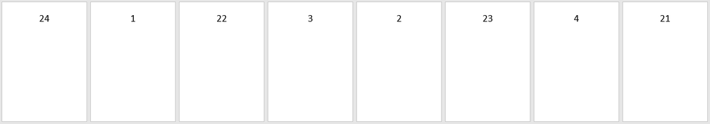

# 138 How to select the bottom grid cell of a data set

```
data_IPONeg_anom[0,:,:,:].bfill('st_ocean').isel({'st_ocean': 0}).plot()
```

# 139 How to select the bottom grid cell that still has data (e.g., for bottom age/temp/sal figs)

If working with 1-dimensional data:

```
bottom_cell = pd.Series(anoms[:,y,x]).last_valid_index()
anoms[bottom_cell,y,x].values
```

If selecting the first valid index, use `pd.Series(ds).first_valid_index()` If working with n-dimensional data, use Denisse Fierro Arcos’s function she just sent me:

```
def extract_bottom_layer(da):
    '''
    Inputs:
    da - Data array from which bottom layer needs to be extracted.
    Output:
    Data array with a single depth layer.
    '''
    # Give a value of 1 to all cells containing environmental data in a single time step
    mask_2d = xr.where(~np.isnan(da.isel(time = 0)), 1, np.nan)
    # Perform a cumulative sum along depth axis to identify deepest grid cell with environmental data
    mask_2d = mask_2d.cumsum('st_ocean').where(~np.isnan(da.isel(time = 0)))
    # Create a mask identifying deepest cells with a value of 1
    mask_2d = xr.where(mask_2d == mask_2d.max('st_ocean'), 1, np.nan)
    # apply mask to original data array
    da = (mask_2d*da).sum('st_ocean')
    # Rearrange dimensions to match original dataset
    da = da.transpose('time', 'yt_ocean', 'xt_ocean')
    # Returning bottom layer
    return da
```